# 0816050 施雅青

## [註] code explanation 以註解方式寫於 ipynb 檔中，此 report 僅包含 result table 與 comparison & conclusion

# Mushroom

## Result [註]此為一次測試中的結果，會因為 shuffle 讓每次的結果稍有差別

#### Holdout without laplace

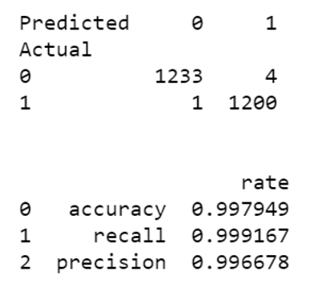

#### Holdout with laplace smoothing

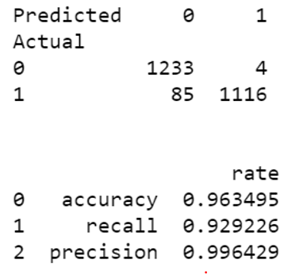

#### K-fold without laplace smoothing

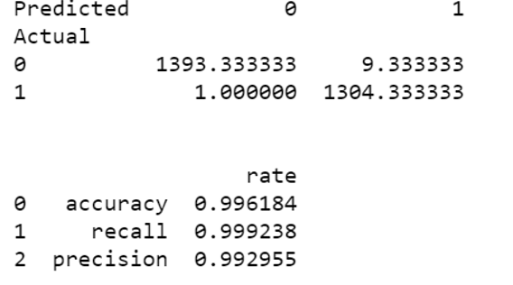

#### K-fold with laplace smoothing

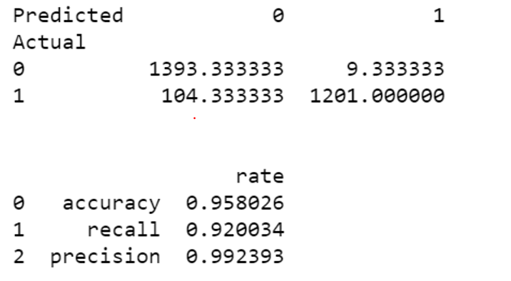

## Comparison and Conclusion

##### comparison

比較 holdout 與 k-fold：可以從結果中看出 k-fold 的準確率等等都比 holdout 要來的低，這是因為 holdout 是以 0.7 的比例去做 training，相比起 k-fold 只用 2/3 的資料進行 training，準確率會較高，但是假如把測試次數調高，可能會看見 holdout 結果比 k-fold 低的情況，這是由於 holdout 沒有挑到更能代表這個 dataset 的資料，因此在 k-fold 的結果會分布的較為平均。

比較有無 laplace smoothing：laplace smoothing 所設置的參數越大，會讓資料產生更大的失真，所以 laplace smoothing 雖然解決了機率為 0 的情況，但同時會帶來準確率的降低。從結果可以看出加上 laplace smoothing，準確率也會跟著下降。

##### conclusion

(1)laplace smoothing 會造成失真導致準確率降低 (2)training 資料量會影響結果

## Question1

#### probability without laplace smoothing

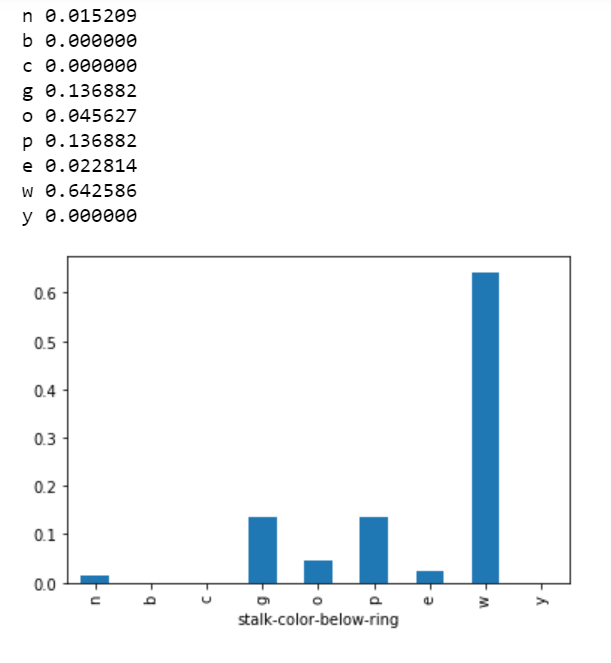

#### probability with laplace smoothing

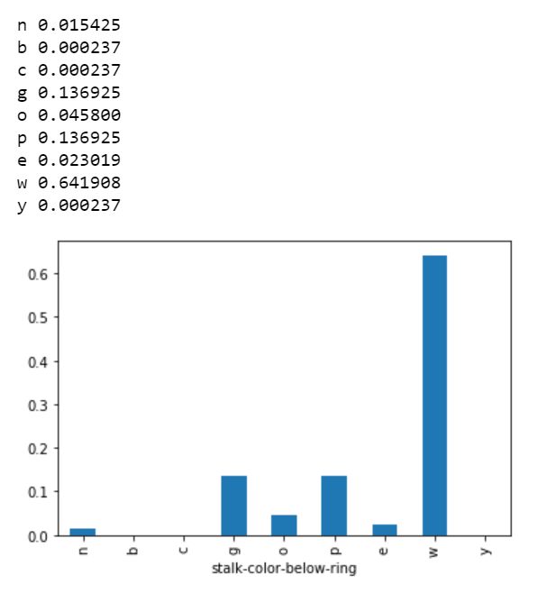

# Iris

## Result

#### holdout

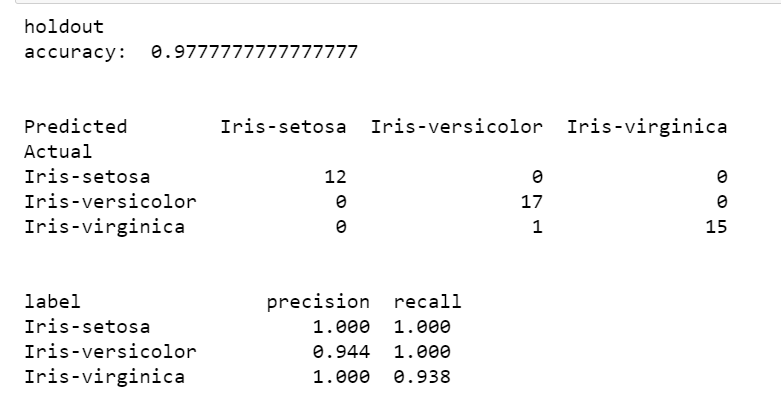

#### K-fold

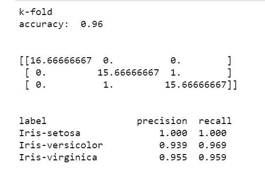

## Compare and Comparison

##### comparison

同在 mushroom 的觀察：k-fold 在多次實驗中結果會較於平均，不同於 mushroom dataset 在 k-fold 的結果中會低於 holdout，iris 在 k-fold 與 holdout 差不多，我想是因為他們的比例使得結果差異不大。

##### conclusion

(1)laplace smoothing 會造成失真導致準確率降低

## Question2

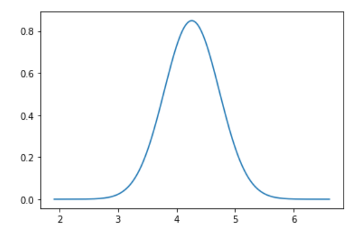